# Neural Network Second List

Dropout and Keras

Author

Micael Egídio Papa da Silva

Published

22-05-2024

In this list, we will use the computational package *Keras* (or another of your preference – *PyTorch*, *TensorFlow*, *Theano*, *H2O*, *Caffe*) to fit deep neural networks. Consider the data and models described in List 1 to answer the following questions.

# Libraries

**Show/hide code**

```python
import numpy as np
import pandas as pd

import scipy.stats as st
import statsmodels.formula.api as smf

import seaborn as sns
import matplotlib.pyplot as plt
import plotly
import plotly.offline
import plotly.graph_objects as go
import plotly.express as px


import time
import warnings


from sklearn.metrics import mean_squared_error, mean_absolute_error, r2_score
from sklearn.neural_network import MLPRegressor
from skopt import gp_minimize
from skopt.space import Real, Integer
from skopt.utils import use_named_args

import tensorflow as tf
import keras
from keras.models import Sequential
from keras.layers import Dense, Dropout, PReLU, Input
from keras.optimizers import Adam, RMSprop
from keras.callbacks import EarlyStopping, ModelCheckpoint, LearningRateScheduler
from sklearn.preprocessing import StandardScaler
from keras.optimizers import SGD
```

## Functions

**Show/hide code**

```python
import numpy as np

import numpy as np
import pandas as pd
import time

import numpy as np
import pandas as pd
import time

class DropoutNetwork:
    def __init__(self):
        self.W_1 = None
        self.W_2 = None
        self.b_1 = None
        self.b_2 = None

    def sigmoid(self, x):
        return 1 / (1 + np.exp(-x))

    def loss(self, y_hat, y):
        return np.mean((y_hat - y) ** 2)

    def derivative_loss(self, y_hat, y):
        return 2 * (y_hat - y) / y.shape[0]

    def set_masks(self, X, dropout_prob):
        self.mask_input = np.random.rand(*X.shape) < dropout_prob
        self.mask_hidden = np.random.rand(2) < dropout_prob

    def forward_pass_dropout(self, X, theta, dropout_prob):
        self.set_masks(X, dropout_prob)

        self.W_1 = theta[:4].reshape(2, 2)
        self.W_2 = theta[4:6].reshape(2, 1)
        self.b_1 = np.tile(theta[6:8].reshape(1, 2), (X.shape[0], 1))
        self.b_2 = theta[8].reshape(1, 1)

        X_dropped = X * self.mask_input
        A_1 = X_dropped @ self.W_1 + self.b_1
        H_1 = self.sigmoid(A_1)
        H_1_dropped = H_1 * self.mask_hidden
        y_hat = H_1_dropped @ self.W_2 + self.b_2

        return y_hat

    def forward_pass_weight_scaling(self, X, theta, dropout_prob):
        self.W_1 = theta[:4].reshape(2, 2)
        self.W_2 = theta[4:6].reshape(2, 1)
        self.b_1 = np.tile(theta[6:8].reshape(1, 2), (X.shape[0], 1))
        self.b_2 = theta[8].reshape(1, 1)

        scaled_W_1 = (dropout_prob) * self.W_1
        scaled_W_2 = (dropout_prob) * self.W_2

        A_1 = X @ scaled_W_1 + self.b_1
        H_1 = self.sigmoid(A_1)
        y_hat = H_1 @ scaled_W_2 + self.b_2

        return y_hat

    def backpropagation_dropout(self, y_hat, y, X, dropout_prob):
        H_1 = self.sigmoid(X @ self.W_1 + self.b_1)
        dA_2 = self.derivative_loss(y_hat, y)

        dW_2 = H_1.T @ dA_2
        db_2 = np.sum(dA_2, axis=0, keepdims=True)

        dH_1 = dA_2 @ self.W_2.T
        dH_1 = dH_1 * self.mask_hidden

        dA_1 = dH_1 * H_1 * (1 - H_1)
        dW_1 = X.T @ dA_1
        db_1 = np.sum(dA_1, axis=0, keepdims=True)

        gradients = np.hstack((dW_1.ravel(), dW_2.ravel(), db_1.ravel(), db_2.ravel()))
        return gradients

    def loss_calculation(self, y_hat, y):
        return self.loss(y_hat, y)

    def train(self, x_train, y_train, learning_rate, epochs, dropout_prob):
        lowest_cost = float('inf')
        best_weights = None
        theta = np.zeros(9, dtype=float)

        for epoch in range(epochs):
            y_hat = self.forward_pass_dropout(x_train, theta, dropout_prob)
            current_cost = self.loss_calculation(y_hat, y_train)

            if current_cost < lowest_cost:
                lowest_cost = current_cost
                best_weights = theta.copy()

            # Backpropagation with dropout
            gradients = self.backpropagation_dropout(y_hat, y_train, x_train, dropout_prob)

            # Gradient descent update
            theta -= learning_rate * gradients

            if (epoch + 1) % 100 == 0:
                print(f'Epoch {epoch + 1}/{epochs}, Loss: {current_cost}')

        print(f'Lowest observed cost: {lowest_cost}')
        return best_weights


def predictions(x_test, batch_size, nn_model, sub_networks=None, dropout_prob=None, theta=None, method='dropout'):
    point_estimates = []
    start_time = time.time()

    if method == 'drop_first_obs':
        x_test_first_observation = x_test[0]

        predictions = [nn_model.forward_pass_dropout(x_test_first_observation, theta, dropout_prob) for theta in sub_networks]

        mean_prediction = np.mean(predictions)
        std_deviation = np.std(predictions)

        confidence_level = 0.95
        z_score = 1.96
        margin_of_error = z_score * (std_deviation / np.sqrt(len(predictions)))
        lower_bound = mean_prediction - margin_of_error
        upper_bound = mean_prediction + margin_of_error

        print(f"Point Estimate for y_1: {mean_prediction:.3f}")
        print(f"Confidence Interval for y_1: ({lower_bound:.3f}, {upper_bound:.3f})")
        print(f"Margin of Error: {margin_of_error:.3f}")

        return None

    else:
        for i in range(0, len(x_test), batch_size):
            x_test_batch = x_test[i:i + batch_size]

            batch_predictions = []
            predictions = []  # Inicializar predictions aqui

            for x_test_observation in x_test_batch:
                if method == 'MCMA':
                    predictions = [nn_model.forward_pass_dropout(x_test_observation, theta, dropout_prob) for theta in sub_networks]
                elif method == 'weight_scaling':
                    predictions = [nn_model.forward_pass_weight_scaling(x_test_observation, theta, dropout_prob)]
                batch_predictions.append(predictions)

            for j, x_test_observation in enumerate(x_test_batch):
                predictions = batch_predictions[j]
                mean_prediction = np.mean(predictions)
                point_estimates.append(mean_prediction)

        df = pd.DataFrame({'Predicted': point_estimates})

        end_time = time.time()
        execution_time = end_time - start_time
        print(f"Execution time for method '{method}': {execution_time:.3f} seconds")

        return df








## Functions for the second question

class CustomNN:
    def __init__(self, x_train, y_train, x_val, y_val, best_hyperparameters):
        self.x_train = x_train
        self.y_train = y_train
        self.x_val = x_val
        self.y_val = y_val
        self.best_hyperparameters = best_hyperparameters

    def create_neural_network(self):
        num_layers, num_neurons, dropout_rate, = self.best_hyperparameters
        model = Sequential()
        model.add(Dense(num_neurons, input_shape=(2,)))
        model.add(PReLU())
        model.add(Dropout(dropout_rate))
        for _ in range(num_layers - 1):
            model.add(Dense(num_neurons))
            model.add(PReLU())
            model.add(Dropout(dropout_rate))
        model.add(Dense(1))
        return model

    def train_model(self):
        num_layers, num_neurons, dropout_rate, = self.best_hyperparameters
        model = self.create_neural_network()

        early_stopping = EarlyStopping(monitor='val_loss', patience=10, restore_best_weights=True)
        model_checkpoint = ModelCheckpoint("best_model.keras", monitor='val_loss', save_best_only=True)

        initial_learning_rate = 0.001
        lr_schedule = tf.keras.optimizers.schedules.ExponentialDecay(
            initial_learning_rate, decay_steps=10000, decay_rate=0.96, staircase=True
        )
        optimizer = Adam(learning_rate=lr_schedule)
        model.compile(optimizer=optimizer, loss='mean_squared_error')

        history = model.fit(self.x_train, self.y_train, validation_data=(self.x_val, self.y_val),
                            epochs=100, batch_size=30, callbacks=[early_stopping, model_checkpoint], verbose=0)


class MAE_NN(CustomNN):
    def train_model_with_predictions(self):

        model = tf.keras.models.load_model("/home/micaelpapa/Desktop/Neural-Nets/best_model.keras")

        y_train_predicted = model.predict(self.x_train)
        y_val_predicted = model.predict(self.x_val)

        new_model = self.create_neural_network()

        early_stopping = EarlyStopping(monitor='val_loss', patience=10, restore_best_weights=True)
        model_checkpoint = ModelCheckpoint("best_parsimonious_model.keras", monitor='val_loss', save_best_only=True)

        initial_learning_rate = 0.001
        lr_schedule = tf.keras.optimizers.schedules.ExponentialDecay(
            initial_learning_rate, decay_steps=10000, decay_rate=0.96, staircase=True
        )
        optimizer = Adam(learning_rate=lr_schedule)
        new_model.compile(optimizer=optimizer, loss='mean_squared_error')

        history = new_model.fit(self.x_train, y_train_predicted, validation_data=(self.x_val, y_val_predicted),
                                epochs=100, batch_size=30, callbacks=[early_stopping, model_checkpoint], verbose=1)




def get_model_info(model):
    num_layers = 0
    dense_layers = []
    dropout_layers = []

    for layer in model.layers:
        if isinstance(layer, tf.keras.layers.Dense):
            num_layers += 1
            dense_layers.append(layer.units)
        elif isinstance(layer, tf.keras.layers.Dropout):
            dropout_layers.append(layer.rate)

    total_neurons = sum(dense_layers) - 1
    dropout_rates = list(set(dropout_layers))

    info_str = (
        f"Number of Dense layers: {num_layers}\n"
        f"Total Neurons: {total_neurons}\n"
        f"Dropout Rates: {dropout_rates}\n"
    )

    for i, units in enumerate(dense_layers, start=1):
        info_str += f"Dense Layer {i}: Neurons: {units}\n"

    return info_str


### Data Vis

def create_parameter_table(theta):
    """
    Create a parameter table DataFrame from a given theta array.

    Parameters:
    - theta (numpy.ndarray): The parameter array containing weights and biases.

    Returns:
    - pd.DataFrame: DataFrame representing the parameter table (transposed).
    """
    theta_list = theta.tolist()
    num_params = len(theta_list) - 3
    num_biases = 3

    param_column_names = [f'w_{i+1}' for i in range(num_params)]
    bias_column_names = [f'b_{i+1}' for i in range(num_biases)]
    column_names = param_column_names + bias_column_names

    parameter_table = pd.DataFrame([theta_list], columns=column_names).T

    parameter_table.columns = ['']

    return parameter_table


def plot_density_heatmap(residuals, title):
    x1 = x_test[:, 0]
    x2 = x_test[:, 1]

    data = pd.DataFrame({
        'x1': x1,
        'x2': x2,
        'residuals': residuals
    })

    fig = px.density_heatmap(data, x='x1', y='x2', z='residuals', nbinsx=40, nbinsy=40, color_continuous_scale='RdBu_r', histfunc='avg')

    fig.update_layout(coloraxis_colorbar=dict(
        title="Magnitude of the Residual",
        titleside="right",
    ))

    fig.update_layout(
        title=title,
        xaxis_title="x1",
        yaxis_title="x2"
    )

    return fig
```

# Questions

## **Question 1**

## **a)**

Modify your code from List 1 (or, if you prefer, the provided sample codes) to implement the dropout technique in the input layer and the intermediate layer. Use $p=0.6$, where $p$ represents the probability of including each neuron. **Attention:** in this item, there is no need to calculate the cost of the network on the validation set! At each new iteration of the optimization algorithm, the current neural network generates random point estimates for the training set observations. These estimates, in turn, are used to calculate the cost on the training set and update the network weights. Report the lowest observed cost during training and save the respective weights to answer the other items in Question 1.

**Show/hide code**

```python
nn_drop = DropoutNetwork()

dropout_prob = 0.6
learning_rate = 0.1
epochs = 100
theta = np.zeros(9)

best_weights = nn_drop.train(x_train, y_train, learning_rate, epochs ,dropout_prob)

create_parameter_table(best_weights.copy())
```

```
Lowest observed cost: 149.5739184976249
```

| w_1 | 0.907781 |
| --- | --- |
| w_2 | 1.627751 |
| w_3 | -4.633402 |
| w_4 | -5.142242 |
| w_5 | 17.947933 |
| w_6 | 17.228316 |
| b_1 | -2.382156 |
| b_2 | -3.082664 |
| b_3 | 16.980814 |

As expected, applying dropout had a negative impact on the loss function, resulting in worse outcomes compared to the previously implemented network. This is due to the low representational capacity of the chosen architecture for this simple neural network.

## **b)**

Considering the weights obtained in **a)**, for the first observation of the test set, generate 200 predictions ($\hat{y}_{1, 1}, \ldots, \hat{y}_{1, 200}$), one for each randomly sampled sub-network. Use the predictions to construct a point estimate and a confidence interval for $y_1$. See Figure 7.6 in the book *Deep Learning*. Note that with this procedure, it is not necessary to assume normality for the errors, as we did in List 1.

Making a 95% confidence interval for the point estimate for the first observation :

**Show/hide code**

```python
batch_size = 30

sub_networks = [np.random.normal(loc=best_weights, scale=0.1) for _ in range(200)]

predictions(x_test, batch_size, nn_drop, sub_networks, dropout_prob, method='drop_first_obs')
```

```
Point Estimate for y_1: 18.446
Confidence Interval for y_1: (18.098, 18.795)
Margin of Error: 0.349
```

## **c)**

Repeat item **b)** to generate point estimates for each observation in the test set.

The Monte Carlo model averaging and the Weight scaling ( next question ) where implemented with the mini batch strategy during inference to optimize the process.

**Show/hide code**

```python
MCMA = predictions(x_test, batch_size, nn_drop, sub_networks, dropout_prob, method='MCMA')  # monte carlo model averaging
 # monte carlo model averaging
```

```
Execution time for method 'MCMA': 51.929 seconds
```

## **d)**

Use the weight scaling inference rule (page 263 of the book *Deep Learning*) to generate new estimates for the observations in the test set. Which of the procedures (the one from item **c)** or the one used in this item) produced better results? Considering the computational time of each, which would you choose for this application?

**Observation:** Note that with the procedure executed in this question, we did not implement the early stopping technique. To use it, at each new iteration of the SGD algorithm, we can calculate the cost on the validation set using item **d)**, and then stop training when the cost on the validation set stops decreasing.

**Show/hide code**

```python
weight_scaling = predictions(x_test, batch_size, nn_drop, dropout_prob=0.6, theta=best_weights, method='weight_scaling')
```

```
Execution time for method 'weight_scaling': 0.284 seconds
```

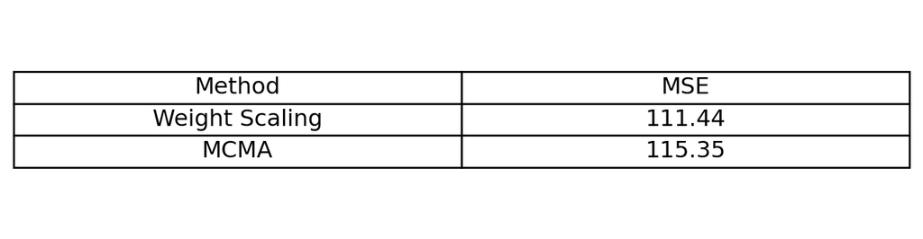

## **Question 2**

## **a)**

Fit the specified neural network using Keras. Compare it with your implementation (List 1, item e) in terms of computational time and the cost obtained on the validation set. Use the same optimization algorithm (full gradient descent) and starting point.

[interactive chart not shown]

Keras implementation :

I’ve tried to create a personalized learning rate schedule to match the same results from before, because SGD (even with momentum set to zero and the mini-batch equal to the train size) tends to keep learning and finding better results than the Vanilla GD, however , even with the `lr_schedule` the first epoch had always miss-match results between the test and validation loss.

**Show/hide code**

```python
start_time = time.time()

## Implementing learning rate schedule to control the loss decay

def lr_schedule(epoch, lr):
    if epoch > 1 and epoch % 12 == 0:
        lr = lr * 0.001
    elif epoch > 14:
        lr = lr * tf.math.exp(-0.001)
    return float(lr)

model = Sequential([
    Dense(2, activation='sigmoid', input_shape=(2,), kernel_initializer='zeros', bias_initializer='zeros'),
    Dense(1)
])

optimizer = SGD(learning_rate=0.1, momentum=0.0)
model.compile(optimizer=optimizer, loss='mean_squared_error')

checkpoint_callback = ModelCheckpoint(filepath='best_weights.weights.h5', save_best_only=True, save_weights_only=True, verbose=0)
lr_scheduler = LearningRateScheduler(lr_schedule)

history = model.fit(x_train, y_train, validation_data=(x_val, y_val),
                    epochs=100, batch_size=len(x_train), validation_batch_size=len(x_val), verbose=0,
                    callbacks=[checkpoint_callback, lr_scheduler], shuffle=False)

end_time = time.time()
execution_time_keras = end_time - start_time
```

[interactive chart not shown]

```
Matrix implementation execution time : 1.551 seconds
Keras execution time : 3.720 seconds
```

## **b)**

Fit the most accurate neural network (measured by MSE calculated on the validation set) that you can achieve, with any architecture you want. Use all regularization techniques you desire (weight decay, Bagging, dropout, Early stopping). Report the accuracy obtained for this network on the validation set.

A bayesian optimization was implemented to find the best architecture in a wide search space with a gaussian process, where the hyperparameters consists in :

- Number of dense layers [1,5]
- Number of neurons [50 , 200 ]
- Dropout rate varying from [0 , 0.5]

Which will be the parameters of the objective function, handled by the Expected Improvement (EI) acquisition function designed to select the next point in the search space that maximizes the expected improvement over the current best observation during the gaussian process.

The Early Stopping was implemented to avoid overfitting

**Show/hide code**

```python
space = [
    Integer(1, 5, name='num_layers'),
    Integer(50, 200, name='num_neurons'),
    Real(0.0, 0.5, name='dropout_rate')
]


@use_named_args(space)
def objective_function(num_layers, num_neurons, dropout_rate):
    model = Sequential()
    model.add(Dense(num_neurons, activation='relu', input_shape=(2,)))
    model.add(Dropout(dropout_rate))
    for _ in range(num_layers - 1):
        model.add(Dense(num_neurons, activation='relu'))
        model.add(Dropout(dropout_rate))
    model.add(Dense(1))

    optimizer = Adam()
    model.compile(optimizer=optimizer, loss='mse')

    history = model.fit(x_train, y_train, validation_data=(x_val, y_val),
                        epochs=10, batch_size=30, verbose=0)

    val_loss = history.history['val_loss'][-1]
    return val_loss


result = gp_minimize(objective_function, space, n_calls=20, random_state=42, acq_func='EI')


best_hyperparameters = result.x
best_num_layers, best_num_neurons, best_dropout_rate = best_hyperparameters


CustomNN(x_train, y_train, x_val, y_val, best_hyperparameters).train_model()
```

```
Best Architecture :
Number of Dense layers: 5
Total Neurons: 800
Dropout Rates: [0.0]
Dense Layer 1: Neurons: 200
Dense Layer 2: Neurons: 200
Dense Layer 3: Neurons: 200
Dense Layer 4: Neurons: 200
Dense Layer 5: Neurons: 1

Validation Loss:1.070
```

**Considering the network adjusted in item b), answer the following questions.**

## **c)**

Repeat item h) from List 1 for this new network. Comment on the results.

**Show/hide code**

```python
y_hats = model.predict(x_val, verbose = 0)

fig = go.Figure(data=go.Scatter(
    x=y_hats.flatten(),
    y=y_val.flatten(),
    mode='markers',
    marker=dict(
        color='blue'
    )))

fig.update_layout(
    title='Observed Value vs. Expected Value ',
    xaxis_title='y&#x0302;<sub>i</sub>',
    yaxis_title='y<sub>i</sub>',
    font=dict(size=14),
    showlegend=False,
    plot_bgcolor='rgba(240, 240, 240, 0.6)',
    hovermode='closest',
    margin=dict(l=50, r=50, t=50, b=50),
)


fig.show()
```

[interactive chart not shown]

With this in mind, as shown in the above plot , we can see a distribution more aligned with the 45-degree line, indicating a more accurate match between the model’s predictions and the actual values.

However, it’s important to note that even with a more complex network, there may still be some scatter in the points due to the presence of noise in the data. Therefore, while we anticipate an overall improvement in the plot’s results with the more complex network, we may still observe some variability in the points around the 45-degree line.

## **d)**

Use the prediction function of Keras to predict the value of the response variable $\hat{y}=f(x_1=1, x_2=1; \theta)$, where $\theta$ is defined according to the adjusted network. (See item a) of List 1).

**Show/hide code**

```python
X = np.array([1] * 2).reshape(1, 2)


print(f"Prediction: {model.predict(X, verbose = 0).flatten()}")
```

```
Prediction: [14.340225]
```

## **e)**

In this purely didactic example, we know the surface we are estimating. Present, side by side, Figure 1 from List 1 and the surface estimated by your neural network. To do this, simply replace the variable `mu` with the values predicted by the network. Comment on the results.

**Show/hide code**

```python
theta = np.zeros(9)


residuals = np.array(y_test - nn.forward_pass(x_test, theta)).flatten()

residuals_new = np.array(y_val - y_hats).flatten()

plot_density_heatmap(residuals, "Surface biases behavior (Simple Architecture)").show()
plot_density_heatmap(residuals_new, "Surface biases behavior (Complex Architecture)").show()
```

[interactive chart not shown]

As expected , the more Complex Architecture presents an ideal range of residuals when compared with the previous network architecture from the first list.

## **f)**

Build a new network, now adjusted on the predicted values (instead of the observed values of $y$) for each observation in the training and validation sets. Use the most parsimonious architecture you can without substantially compromising the predictive power of the network (compared to the one obtained in item 2b). Mention a possible use for this new network.

For this question we will apply a bayesian optimization to find the best parsimonious architcture within a simpler search space:

**Show/hide code**

```python
space = [
    Integer(1, 3, name='num_layers'),
    Integer(10, 50, name='num_neurons'),
    Real(0.0, 0.5, name='dropout_rate')
]

@use_named_args(space)

def objective_function(num_layers, num_neurons, dropout_rate):

    model = tf.keras.models.load_model("/home/micaelpapa/Desktop/Neural-Nets/best_model.keras")
    y_train_predicted = model.predict(x_train)
    y_val_predicted = model.predict(x_val)

    new_model = Sequential()
    new_model.add(Dense(num_neurons, activation='relu', input_shape=(2,)))
    new_model.add(Dropout(dropout_rate))
    for _ in range(num_layers - 1):
        new_model.add(Dense(num_neurons, activation='relu'))
        new_model.add(Dropout(dropout_rate))
    new_model.add(Dense(1))

    optimizer = Adam()
    new_model.compile(optimizer=optimizer, loss='mse')

    early_stopping = EarlyStopping(monitor='val_loss', patience=10, restore_best_weights=True)
    model_checkpoint = ModelCheckpoint("best_parsimonious_model.keras", monitor='val_loss', save_best_only=True)


    history = new_model.fit(x_train, y_train_predicted, validation_data=(x_val, y_val_predicted),
                            epochs=100, batch_size=30, callbacks=[early_stopping, model_checkpoint], verbose=1)

    val_loss = history.history['val_loss'][-1]
    return val_loss

result = gp_minimize(objective_function, space, n_calls=20, random_state=42, acq_func='EI')

best_hyperparameters = result.x

MAE_NN(x_train, y_train, x_val, y_val, best_hyperparameters).train_model()
```

```
Best parsimonious architecture:
Number of Dense layers: 4
Total Neurons: 132
Dropout Rates: [0.0]
Dense Layer 1: Neurons: 44
Dense Layer 2: Neurons: 44
Dense Layer 3: Neurons: 44
Dense Layer 4: Neurons: 1

Validation Loss:0.035
```

Assuming for simplicity :

- **Model A : Complex Network**
- **Model B : Parsimonious Network**

We can mathematically formulate the process by which Model B predicts the errors of Model A.

Let $Y$ be the target variable we want to predict. Model A makes its predictions as $\hat{Y}_A$, and Model B makes its predictions as $\hat{Y}_B$.

We can represent the predictions of Model A as:

$$\hat{Y}_A = f_A(X_1, X_2) + \epsilon_A$$

Where $f_A(X_1, X_2)$ is the function that Model A learns to predict $Y$, and $\epsilon_A$ are the errors or residuals associated with these predictions.

Model B is trained to predict these errors $\epsilon_A$ from Model A. So, we can represent the predictions of Model B as:

$$\hat{\epsilon}_B = g_B(X_1, X_2)$$

Where $g_B(X_1, X_2)$ is the function that Model B learns to predict the errors of Model A.

The final combined prediction, $\hat{Y}_{\text{combined}}$, can be expressed as the sum of the predictions from Model A and the predictions from Model B:

$$\hat{Y}_{\text{combined}} = \hat{Y}_A + \hat{\epsilon}_B$$

Substituting the expressions for $\hat{Y}_A$ and $\hat{\epsilon}_B$, we get:

$$\hat{Y}_{\text{combined}} = f_A(X_1, X_2) + g_B(X_1, X_2)$$

Therefore, Model B makes its predictions by adjusting the predictions of Model A based on the error patterns it learns during training. This allows Model B to capture and correct the errors or residuals associated with the predictions of Model A, potentially improving the overall accuracy of the combined model.

On that note, we can adjust the predictions considering the learned error patterns from simpler model :

**Show/hide code**

```python
actual_values = y_val

predictions = y_hats

errors = y_val - model_parsimonious.predict(x_val, verbose = 0)


predictions_combined = predictions + errors


## model_a = complex network

mse_model_a = mean_squared_error(actual_values, predictions)
rmse_model_a = np.sqrt(mse_model_a)
mae_model_a = mean_absolute_error(actual_values, predictions)
r2_model_a = r2_score(actual_values, predictions)

mse_combined = mean_squared_error(actual_values, predictions_combined)
rmse_combined = np.sqrt(mse_combined)
mae_combined = mean_absolute_error(actual_values, predictions_combined)
r2_combined = r2_score(actual_values, predictions_combined)

print("Metrics for the Complex network:")
print(f"MSE: {mse_model_a:.3f}")
print(f"MAE: {mae_model_a:.3f}")

print("\nMetrics for Combined Predictions:")
print(f"MSE: {mse_combined:.3f}")
print(f"MAE: {mae_combined:.3f}")
```

```
Metrics for the Complex network:
MSE: 1.070
MAE: 0.825

Metrics for Combined Predictions:
MSE: 0.035
MAE: 0.143
```

As expected, we can see a notable improvement into the MSE and MAE.